# 教学文档 1：医学专家共识 Modified Delphi 全流程

Ming Yang

2026-09-14

# 1. 这份文档解决什么问题

本教程从零演示如何用 **delphir** 完成一项医学专家共识（Modified Delphi）：

1. 先写清问题、使用者和地理范围；
2. **在看数据之前**锁定共识阈值；
3. 读入（或模拟）专家、条目、评分和意见；
4. 计算参与度、Median / IQR / 赞同率；
5. 按复合标准判定高度共识、基本共识、临界、排除、两极分化；
6. 看稳定性、分层和脱落偏倚；
7. 制作下一轮受控反馈；
8. 输出符合 ACCORD 结构的报告，并解读每一张表。

使用的样本是包内数据集 `consensus_demo`：40 名专家、20 条临床试验质量条目、两轮 9 分 Likert。数据**故意不完美**，含脱落、无法判断、临界条目和两极分化。

```r
library(delphir)
data("consensus_demo", package = "delphir")
consensus_demo
```

```
#> Delphi 研究
#>   题目: 药物临床试验质量源于设计实施专家共识（模拟数据）
#>   场景: 医学专家共识（Modified Delphi）
#>   专家: 40 人；条目: 20；轮次: 1, 2
#>   评分行数: 2230
```

# 2. 方法学边界：Delphi 不是证据评价

Delphi 适合回答的是：

> 在证据不足、不一致，或即使有证据仍需做价值判断时，如何系统整合多位专家的判断。

它不适合代替系统评价或 GRADE。比较稳妥的框架是：

**证据检索与评价 → 形成候选条目 → Delphi → 共识会议 → 定稿**

本示例的 `meta$evidence_note` 记录了条目来自法规与方法学综述后的初始条目池，对应 Modified Delphi（第一轮即评分），而不是经典 Delphi 的开放式第一轮。

```r
unlist(consensus_demo$meta)
```

```
#>                                                           title
#>              "药物临床试验质量源于设计实施专家共识（模拟数据）"
#>                                                       objective
#>        "就临床试验方案设计与实施中的关键质量要求形成专家共识。"
#>                                                           users
#>                      "申办者、研究者、伦理委员会与监管相关人员"
#>                                                       geography
#>                                                      "中国大陆"
#>                                                   evidence_note
#> "条目来自 ICH E6(R3)、GCP 及方法学综述后的初始条目池（模拟）。"
#>                                                    pilot_tested
#>                                                          "TRUE"
#>                                                       anonymity
#>                                    "评分匿名；报告仅汇总统计。"
#>                                                          ethics
#>                                  "教学模拟数据，无需伦理审查。"
```

**解读：** ACCORD 要求报告目标、目标使用者和地理范围。这里目的是“临床试验质量要求”，使用者是申办者/研究者/伦理与监管，范围为中国大陆。缺任何一项，发表时都会被审稿人问。

# 3. 第一步：预先锁定方案（不可事后改阈值）

Diamond 等的系统评价表明，文献里的共识定义差异很大，最常见阈值中位数约为 75%。**正确原则不是“必须 ≥70%”，而是第一轮前写明阈值及其理由。**

医学专家共识推荐复合标准，而不是只看一个百分比：

- 高度共识：P(7–9) ≥ 80%，且 Median ≥ 7，且 IQR ≤ 2
- 基本共识：75% ≤ P(7–9) < 80%，且 Median ≥ 7
- 倾向排除：P(1–3) ≥ 75%
- 两极分化：两端同时达到 25%

```r
protocol <- preset_protocol("clinical_consensus")
protocol
```

```
#> Delphi 分析方案
#>   场景: clinical_consensus (医学专家共识（Modified Delphi）)
#>   量表: 1–9  (低 1–3 / 中 4–6 / 高 7–9)
#>   锁定: 是
```

如果因高风险推荐把 80% 改成 85%，必须写 `rationale`，报告会打印“方案偏离预设”。

```r
stricter <- delphi_protocol(
  scenario = "clinical_consensus",
  high_pct = 0.85,
  rationale = "涉及受试者安全的硬性要求，将高度共识提高到 85%。"
)
stricter$modified_from_preset
```

```
#> [1] TRUE
```

**常见错误：** 看到结果后把阈值改成“刚好能过”的 75%。这在方法学上不成立。`classify_consensus()` 也没有阈值参数，防止分析阶段静默改规则。

# 4. 数据长什么样

评分必须是**长表**：一行 = 一位专家 × 一条目 × 一轮 × 一个维度。

```r
head(consensus_demo$panel[, c("expert_id", "stakeholder", "years", "Ca", "Cs")])
```

```
#>   expert_id stakeholder years   Ca   Cs
#> 1       E01    临床医生    13 0.80 0.69
#> 2       E02    临床医生    25 0.78 0.90
#> 3       E03    临床医生    30 0.86 0.82
#> 4       E04    临床医生    16 0.72 0.66
#> 5       E05    临床医生    31 0.80 0.67
#> 6       E06    临床医生    16 0.89 0.81
```

```r
head(consensus_demo$items[, c("item_id", "item_text", "domain", "pattern")])
```

```
#>   item_id                                        item_text   domain
#> 1     C01 随机对照试验应在方案中预先规定补救治疗启动标准。     实施
#> 2     C02         主要疗效指标应预先明确缺失数据处理策略。     实施
#> 3     C03                 方案应定义临床试验重大方案偏离。     报告
#> 4     C04               知情同意过程应记录受试者理解确认。     统计
#> 5     C05             安全性数据应采用预先定义的编码词典。 方案设计
#> 6     C06         中期分析的统计学边界应在方案中预先规定。     统计
#>         pattern
#> 1 converge_high
#> 2 converge_high
#> 3 converge_high
#> 4 converge_high
#> 5 converge_high
#> 6 converge_high
```

```r
head(consensus_demo$ratings)
```

```
#>   expert_id item_id round score dimension unable stakeholder
#> 1       E01     C01     1     9    重要性  FALSE    临床医生
#> 2       E01     C01     1     8    可行性  FALSE    临床医生
#> 3       E01     C02     1     8    重要性  FALSE    临床医生
#> 4       E01     C02     1     6    可行性  FALSE    临床医生
#> 5       E01     C03     1     5    重要性  FALSE    临床医生
#> 6       E01     C03     1     5    可行性  FALSE    临床医生
```

**解读：**

- `unable = TRUE` 表示“超出本人专业领域”，**不得计入 1–9 分母**。
- 本示例第 1 轮同时评了“重要性”和“可行性”，用来发现“很重要但几乎不可实施”的条目。
- `pattern` 只存在于模拟数据，真实研究不会有这一列；它帮助教学识别条目原型。

也可以从外部 CSV 组装对象（包内 `inst/extdata` 提供了同样结构的样例）：

```r
ex <- system.file("extdata", "consensus_ratings.csv", package = "delphir")
if (nzchar(ex)) {
  raw <- utils::read.csv(ex, fileEncoding = "UTF-8")
  cat("外部评分表示例行数:", nrow(raw), "\n")
}
```

```
#> 外部评分表示例行数: 2230
```

# 5. 参与度：积极系数与更重要的脱落

```r
part <- response_summary(consensus_demo)
part$by_round
```

```
#>   round n_invited n_responded response_rate
#> 1     1        40          40         100.0
#> 2     2        40          37          92.5
```

```r
part$retention
```

```
#>   from_round to_round n_previous n_retained n_lost n_new retention_rate
#> 1          1        2         40         37      3     0           92.5
```

**解读：**

- 第 1 轮 40/40 = 100%，第 2 轮 37/40 = 92.5%。国内常称“专家积极系数”，本质就是回收率，值得报告。
- 对 Delphi 更关键的是 **retention**：37/40 = 92.5%。若脱落集中在某一利益相关者组，最终共识可能被扭曲。
- DCAT 把专家保留作为附加质量项。

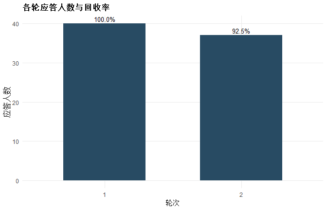

```r
plot_attrition(consensus_demo)
```

# 6. 权威系数 Cr：可以报，但不能当科学性主证据

```r
auth <- expert_authority(consensus_demo$panel)
attr(auth, "overall")
```

```
#> $mean_ca
#> [1] 0.82
#>
#> $mean_cs
#> [1] 0.778
#>
#> $mean_cr
#> [1] 0.799
#>
#> $pct_ok
#> [1] 97.5
#>
#> $threshold
#> [1] 0.7
#>
#> $note
#> [1] "Cr 不是国际 Delphi（DCAT）核心指标，仅供国内发表补充报告。它描述专家相对本次主题的自评权威程度，不应用于加权 Likert 评分，也不必在第二轮重评。"
```

```r
authority_scales()$cs
```

```
#>   很熟悉   较熟悉     一般 不太熟悉   不熟悉
#>      1.0      0.8      0.6      0.4      0.2
```

```r
authority_scales()$ca
```

```
#>           source        key large medium small
#> 1       实践经验   practice   0.5    0.4   0.3
#> 2       理论分析     theory   0.3    0.2   0.1
#> 3 参考国内外文献 literature   0.1    0.1   0.1
#> 4       直观感觉  intuition   0.1    0.1   0.1
```

**解读：**

- (Cr=(Ca+Cs)/2)。Ca 来自判断依据（实践/理论/文献/直觉），Cs 来自熟悉程度。默认赋分见表；必须在第 1 轮前锁定。
- **按专家评一次**，不要对每个条目再填一套。条目不熟请勾选「无法判断」（`unable`），不要再算条目级 Cr。
- 国内常以组均数 0.70 为参考。DCAT 的四个核心特征是匿名、迭代、受控反馈、统计汇总，**不包括 Cr**。
- `Cr = 0.90` 不能证明专家选择科学；构成偏差（例如全是同一专科）才是更大问题。不要用 Cr 加权 1–9 分，第 2 轮也不必重评权威系数。
- 若问卷里是「较熟悉 / 大 / 中 / 小」勾选而不是现成小数，用 `score_authority()` 赋分。从空白问卷到第 2 轮反馈单的完整流程见 `vignette("questionnaire-workflow", package = "delphir")`。

# 7. 第一轮条目汇总：位置 + 离散 + 比例

```r
s1 <- summarize_items(consensus_demo, rounds = 1, dimensions = "重要性")
s1[, c("item_id", "n_valid", "n_unable", "median_iqr", "p_high", "p_low", "cv", "polarized")]
```

```
#>    item_id n_valid n_unable median_iqr   p_high     p_low        cv polarized
#> 1      C01      40        0    8 (7–9) 85.00000  0.000000 0.1647464     FALSE
#> 2      C02      40        0    8 (7–9) 85.00000  2.500000 0.1957787     FALSE
#> 3      C03      40        0    8 (6–9) 70.00000  0.000000 0.1805311     FALSE
#> 4      C04      38        2    8 (7–9) 81.57895  2.631579 0.1960696     FALSE
#> 5      C05      40        0    8 (7–9) 80.00000  2.500000 0.1887733     FALSE
#> 6      C06      39        1    7 (6–9) 69.23077  5.128205 0.2470050     FALSE
#> 7      C07      40        0    8 (7–8) 85.00000  5.000000 0.1997338     FALSE
#> 8      C08      40        0    7 (6–8) 70.00000  2.500000 0.2229078     FALSE
#> 9      C09      40        0    7 (6–8) 70.00000 10.000000 0.2900546     FALSE
#> 10     C10      40        0    7 (5–8) 62.50000  7.500000 0.2942315     FALSE
#> 11     C11      40        0    7 (5–7) 57.50000 17.500000 0.3530565     FALSE
#> 12     C12      40        0    5 (2–7) 30.00000 35.000000 0.5126348      TRUE
#> 13     C13      40        0    4 (4–7) 30.00000 25.000000 0.5026348      TRUE
#> 14     C14      40        0    5 (3–6) 22.50000 27.500000 0.4546993     FALSE
#> 15     C15      38        2    2 (1–8) 31.57895 57.894737 0.7801913      TRUE
#> 16     C16      38        2    5 (2–8) 42.10526 39.473684 0.5828261      TRUE
#> 17     C17      40        0    3 (1–5)  2.50000 55.000000 0.6299089     FALSE
#> 18     C18      40        0    6 (5–8) 50.00000  7.500000 0.3227145     FALSE
#> 19     C19      40        0    5 (4–7) 30.00000 20.000000 0.4094974     FALSE
#> 20     C20      40        0    7 (5–8) 55.00000  5.000000 0.2630309     FALSE
```

**解读每一列：**

- `n_valid`：真正进入 1–9 的人数；`n_unable` 单独报告。
- `median_iqr`：如 `8 (7–9)` 表示中位数 8、四分位距从 7 到 9。Likert 是有序数据，**Median 通常优于 Mean**。
- `p_high` / `p_low`：7–9 与 1–3 的百分比。分布比“平均分 8.1”信息量大得多。
- `cv`：SD/Mean，国内常用补充指标。有序数据上 Median+IQR 更稳健。
- `polarized`：两端同时 ≥25%。均数接近 5 往往不是“大家觉得一般”，而是严重分裂。

对比两条 Median 相同、IQR 不同的条目：

```r
s1[order(-s1$median, -s1$iqr), c("item_id", "median", "iqr", "p_high")][1:8, ]
```

```
#>    item_id median iqr   p_high
#> 3      C03      8   3 70.00000
#> 1      C01      8   2 85.00000
#> 2      C02      8   2 85.00000
#> 4      C04      8   2 81.57895
#> 5      C05      8   2 80.00000
#> 7      C07      8   1 85.00000
#> 6      C06      7   3 69.23077
#> 10     C10      7   3 62.50000
```

**方法学提醒：** 只报告 Mean±SD，是 Delphi 论文最常见的错误之一。

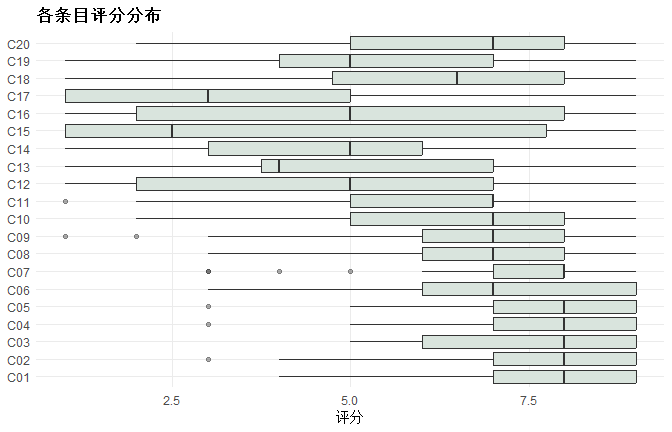

```r
plot_item_distribution(consensus_demo, round = 1, dimension = "重要性")
```

# 8. 按锁定方案判定共识

```r
c1 <- classify_consensus(s1, consensus_demo$protocol)
table(c1$class_zh)
```

```
#>
#> 高度共识 两极分化     临界 未达共识
#>        5        4        3        8
```

```r
c1[, c("item_id", "p_high", "median", "iqr", "class_zh", "action")]
```

```
#>    item_id   p_high median  iqr class_zh  action
#> 1      C01 85.00000    8.0 2.00 高度共识    keep
#> 2      C02 85.00000    8.0 2.00 高度共识    keep
#> 3      C03 70.00000    8.0 3.00     临界 discuss
#> 4      C04 81.57895    8.0 2.00 高度共识    keep
#> 5      C05 80.00000    8.0 2.00 高度共识    keep
#> 6      C06 69.23077    7.0 3.00 未达共识 discuss
#> 7      C07 85.00000    8.0 1.00 高度共识    keep
#> 8      C08 70.00000    7.0 2.00     临界 discuss
#> 9      C09 70.00000    7.0 2.00     临界 discuss
#> 10     C10 62.50000    7.0 3.00 未达共识 discuss
#> 11     C11 57.50000    7.0 2.00 未达共识 discuss
#> 12     C12 30.00000    5.0 5.00 两极分化 discuss
#> 13     C13 30.00000    4.0 3.25 两极分化 discuss
#> 14     C14 22.50000    5.0 3.00 未达共识 discuss
#> 15     C15 31.57895    2.5 6.75 两极分化 discuss
#> 16     C16 42.10526    5.0 6.00 两极分化 discuss
#> 17     C17  2.50000    3.0 4.00 未达共识 discuss
#> 18     C18 50.00000    6.5 3.25 未达共识 discuss
#> 19     C19 30.00000    5.0 3.00 未达共识 discuss
#> 20     C20 55.00000    7.0 3.00 未达共识 discuss
```

**解读分类，而不是只看“过没过”：**

- **高度共识 / keep：** 原则上下一轮可不再重评，或仅确认；共识会议不应轻易推翻。
- **基本共识 / keep：** 过了 75% 但未达 80% 或 IQR 偏大，写入共识时语气宜保留弹性。
- **临界 / discuss：** 70%–75% 一带，机械删除最危险。应先读自由意见、改表述，再进入下一轮。
- **两极分化 / discuss：** 说明存在稳定的价值冲突，正确结论可能就是“未形成共识”。
- **倾向排除 / drop：** 低区达 75%，倾向删除，仍应记录反对理由。

# 9. 为什么不能只看平均分或 Kendall W

构造一个教学对照（不是本数据集）：

```r
detect_polarization(p_high = c(0, 50), p_low = c(0, 50))
```

```
#> [1] FALSE  TRUE
```

```r
coefficient_variation(c(8, 8, 8, 8))
```

```
#> [1] 0
```

```r
coefficient_variation(c(1, 1, 1, 9, 9, 9))
```

```
#> [1] 0.8763561
```

Kendall W 评价的是**一组项目的相对排序**是否协调，适合优先级排序。本例问题是“每条是否重要”，W 只能当补充。

```r
kw <- kendall_w(consensus_demo, round = 1, dimension = "重要性")
kw
```

```
#> $w
#> [1] 0.2925235
#>
#> $chi_sq
#> [1] 200.0861
#>
#> $df
#> [1] 19
#>
#> $p_value
#> [1] 3.273189e-32
#>
#> $n_expert
#> [1] 36
#>
#> $n_item
#> [1] 20
#>
#> $note
#> [1] "W 评价的是排序协调性，不是条目级共识。"
```

**错误推论：** “W 显著，P<0.05，因此形成专家共识。” 显著性依赖样本量，也不能说明每一条都达成共识。

# 10. 自由文本：不要把条件性支持当成反对

```r
q1 <- summarize_comments(study = consensus_demo, round = 1)
q1$by_theme
```

```
#>        theme  n
#> 4   新增内容 13
#> 5       支持 12
#> 3 条件性支持 10
#> 1   表述问题  9
#> 2       反对  8
```

```r
head(q1$by_item)
```

```
#>    item_id    theme n
#> 1      C09 表述问题 1
#> 2      C11 表述问题 1
#> 6      C15 表述问题 1
#> 7      C16 表述问题 2
#> 10     C20 表述问题 4
#> 14     C13     反对 1
```

**解读：** “我赞成本条，但仅适用于高风险干预性研究”不是反对，而是**条件性支持**。ACCORD 要求说明自由文本如何做内容/主题分析。delphir 只汇总你已经编码的 `theme`，不会用黑盒模型替你定性。

方法学组据此修改条目后，必须把修改理由反馈给专家，这才是受控反馈的一部分。

# 11. 制作第 2 轮个性化反馈单

真正的 Delphi 不是把同一张表再发一次。DCAT 要求：组结果 + **本人上一轮评分**。

```r
fb <- prepare_feedback(consensus_demo, round = 1, dimension = "重要性")
fb[fb$expert_id == fb$expert_id[1],
   c("item_id", "own_score", "median_iqr", "p_high", "class_zh", "anonymous_comments")]
```

```
#>    item_id own_score median_iqr   p_high class_zh
#> 1      C01         9    8 (7–9) 85.00000 高度共识
#> 2      C02         8    8 (7–9) 85.00000 高度共识
#> 3      C03         5    8 (6–9) 70.00000     临界
#> 4      C04         7    8 (7–9) 81.57895 高度共识
#> 5      C05         9    8 (7–9) 80.00000 高度共识
#> 6      C06         9    7 (6–9) 69.23077 未达共识
#> 7      C07         9    8 (7–8) 85.00000 高度共识
#> 8      C08         5    7 (6–8) 70.00000     临界
#> 9      C09         2    7 (6–8) 70.00000     临界
#> 10     C10         8    7 (5–8) 62.50000 未达共识
#> 11     C11         8    7 (5–7) 57.50000 未达共识
#> 12     C12         5    5 (2–7) 30.00000 两极分化
#> 13     C13         6    4 (4–7) 30.00000 两极分化
#> 14     C14         6    5 (3–6) 22.50000 未达共识
```

[output cut: 27 more lines]

# 12. 第二轮与稳定性

```r
res <- analyze_delphi(consensus_demo)
res
```

```
#> Delphi 分析结果
#>   场景: 医学专家共识（Modified Delphi）
#>   题目: 药物临床试验质量源于设计实施专家共识（模拟数据）
#>   轮次: 1, 2
#>   参与度:
#>     第 1 轮  40/40  (100.0%)
#>     第 2 轮  37/40  (92.5%)
#>   末轮分类:
#>     高度共识: 9
#>     基本共识: 3
#>     两极分化: 2
#>     临界: 1
#>     倾向排除: 1
#>     未达共识: 4
#>   稳定性建议终止: 否
```

```r
last <- res$last_classification
last[, c("item_id", "median_iqr", "p_high", "p_low", "class_zh", "action")]
```

```
#>    item_id median_iqr    p_high     p_low class_zh  action
#> 41     C01    8 (7–9)  94.59459  0.000000 高度共识    keep
#> 42     C02    8 (8–9)  91.89189  0.000000 高度共识    keep
#> 43     C03    8 (8–9)  94.59459  0.000000 高度共识    keep
#> 44     C04    8 (8–9)  97.29730  0.000000 高度共识    keep
#> 45     C05    9 (8–9)  89.18919  0.000000 高度共识    keep
#> 46     C06    8 (7–9)  91.89189  0.000000 高度共识    keep
#> 47     C07    8 (8–9) 100.00000  0.000000 高度共识    keep
#> 48     C08    8 (7–9)  89.18919  0.000000 高度共识    keep
#> 49     C09    7 (7–9)  75.67568 10.810811 基本共识    keep
#> 50     C10    7 (6–8)  70.27027  5.405405     临界 discuss
#> 51     C11    7 (7–8)  81.08108  8.108108 高度共识    keep
#> 52     C12    5 (3–6)  24.32432 27.027027 未达共识 discuss
#> 53     C13    6 (4–6)  24.32432 18.918919 未达共识 discuss
#> 54     C14    4 (2–6)  21.62162 40.540541 未达共识 discuss
#> 55     C15    3 (1–8)  37.83784 54.054054 两极分化 discuss
#> 56     C16    4 (1–9)  41.66667 38.888889 两极分化 discuss
#> 57     C17    2 (2–3)   0.00000 75.675676 倾向排除    drop
#> 58     C18    8 (7–9)  78.37838  8.108108 基本共识    keep
#> 59     C19    8 (7–8)  75.67568  5.405405 基本共识    keep
#> 60     C20    8 (5–8)  64.86486 16.216216 未达共识 discuss
```

过程透明表（CREDES / ACCORD 要求分轮报告）：

```r
wide <- res$classification
wide <- wide[wide$dimension == "重要性",
             c("item_id", "round", "median_iqr", "p_high", "class_zh")]
wide
```

```
#>    item_id round median_iqr    p_high class_zh
#> 21     C01     1    8 (7–9)  85.00000 高度共识
#> 22     C02     1    8 (7–9)  85.00000 高度共识
#> 23     C03     1    8 (6–9)  70.00000     临界
#> 24     C04     1    8 (7–9)  81.57895 高度共识
#> 25     C05     1    8 (7–9)  80.00000 高度共识
#> 26     C06     1    7 (6–9)  69.23077 未达共识
#> 27     C07     1    8 (7–8)  85.00000 高度共识
#> 28     C08     1    7 (6–8)  70.00000     临界
#> 29     C09     1    7 (6–8)  70.00000     临界
#> 30     C10     1    7 (5–8)  62.50000 未达共识
#> 31     C11     1    7 (5–7)  57.50000 未达共识
#> 32     C12     1    5 (2–7)  30.00000 两极分化
#> 33     C13     1    4 (4–7)  30.00000 两极分化
#> 34     C14     1    5 (3–6)  22.50000 未达共识
```

[output cut: 26 more lines]

```r
head(res$stability[, c("item_id", "median_r1", "median_r2", "p_high_r1",
                       "p_high_r2", "class_unchanged", "wilcoxon_p")])
```

```
#>   item_id median_r1 median_r2 p_high_r1 p_high_r2 class_unchanged  wilcoxon_p
#> 1     C01         8         8  85.00000  94.59459            TRUE 0.869732659
#> 2     C02         8         8  85.00000  91.89189            TRUE 0.162977400
#> 3     C03         8         8  70.00000  94.59459           FALSE 0.008671445
#> 4     C04         8         8  81.57895  97.29730            TRUE 0.030375270
#> 5     C05         8         9  80.00000  89.18919            TRUE 0.051302964
#> 6     C06         7         8  69.23077  91.89189           FALSE 0.025506723
```

```r
res$stopping
```

```
#> $recommend_stop
#> [1] FALSE
#>
#> $class_unchanged_pct
#> [1] 0.45
#>
#> $median_stable_pct
#> [1] 0.85
#>
#> $p_high_stable_pct
#> [1] 0.6
#>
#> $max_rounds
#> [1] 3
#>
#> $current_round
#> [1] 2
#>
#> $note
#> [1] "Wilcoxon P>0.05 不能单独定义为意见稳定，因为 P 值依赖样本量。"
```

**解读稳定性：**

[figure not shown]

```r
plot_round_shift(res, metric = "p_high")
```

本方案的停止规则：最多 3 轮；相邻轮分类不变 ≥80%；Median 变化 ≤1；高区比例变化 <10%。未达则应考虑针对争议条目做第 3 轮。**不是所有条目都必须达成共识。**

# 13. 分层与脱落偏倚

```r
head(res$stakeholder[, c("item_id", "group_level", "n_valid", "median", "p_high", "class_zh")])
```

```
#>   item_id group_level n_valid median    p_high class_zh
#> 1     C01    临床医生      18    8.0  94.44444 高度共识
#> 2     C02    临床医生      18    8.0  88.88889 高度共识
#> 3     C03    临床医生      18    8.0 100.00000 高度共识
#> 4     C04    临床医生      18    8.0 100.00000 高度共识
#> 5     C05    临床医生      18    9.0  94.44444 高度共识
#> 6     C06    临床医生      18    8.5  94.44444 高度共识
```

**解读：** 即使总体过线，若方法学专家与临床医生方向相反，必须在报告中写出来。COMET 尤其强调这一点；临床共识同样适用。

```r
head(res$dropout)
```

```
#>   item_id dimension n_completer n_dropout median_completer median_dropout
#> 1     C01    重要性          37         3                8              6
#> 2     C02    重要性          37         3                8              9
#> 3     C03    重要性          37         3                8              9
#> 4     C04    重要性          35         3                8              8
#> 5     C05    重要性          37         3                8              9
#> 6     C06    重要性          36         3                7              8
#>   p_high_completer p_high_dropout wilcoxon_p
#> 1         89.18919       33.33333 0.01938609
#> 2         83.78378      100.00000 0.12202376
#> 3         67.56757      100.00000 0.13054152
#> 4         80.00000      100.00000 0.49914029
#> 5         78.37838      100.00000 0.21763451
#> 6         69.44444       66.66667 0.76582939
```

若脱落者在关键条目上系统更反对，最终赞同率可能被高估。这是“没有报告脱落”之所以危险的原因。

# 14. 可行性维度：重要但不一定能做

```r
feas <- classify_consensus(
  summarize_items(consensus_demo, rounds = 1, dimensions = "可行性"),
  consensus_demo$protocol
)
cmp <- merge(
  last[, c("item_id", "p_high", "class_zh")],
  feas[, c("item_id", "p_high", "class_zh")],
  by = "item_id", suffixes = c("_重要性", "_可行性")
)
head(cmp)
```

```
#>   item_id p_high_重要性 class_zh_重要性 p_high_可行性 class_zh_可行性
#> 1     C01      94.59459        高度共识      80.00000        高度共识
#> 2     C02      91.89189        高度共识      77.14286        基本共识
#> 3     C03      94.59459        高度共识      67.56757        未达共识
#> 4     C04      97.29730        高度共识      82.35294        高度共识
#> 5     C05      89.18919        高度共识      82.85714        高度共识
#> 6     C06      91.89189        高度共识      75.86207        基本共识
```

**解读：** “非常重要但几乎不可实施”的条目，若只有一个“是否同意”分数就会丢失。指标体系场景更要把重要性、可操作性、可测量性拆开。

# 15. 共识会议怎么开

已达高度共识的条目，原则上不要在 10 人会议上推翻 40 人的匿名结果。会议重点：

- 临界与无共识；
- 利益相关者相反；
- 原则已共识、文字需改。

再次表决建议匿名电子投票。

```r
table(last$action, last$class_zh)
```

```
#>
#>           高度共识 基本共识 两极分化 临界 倾向排除 未达共识
#>   discuss        0        0        2    1        0        4
#>   drop           0        0        0    0        1        0
#>   keep           9        3        0    0        0        0
```

# 16. 证据与共识必须分列

```r
last[, c("item_id", "evidence_level", "p_high", "class_zh")]
```

```
#>    item_id evidence_level    p_high class_zh
#> 41     C01       系统评价  94.59459 高度共识
#> 42     C02       专家意见  91.89189 高度共识
#> 43     C03            RCT  94.59459 高度共识
#> 44     C04  法规/指导原则  97.29730 高度共识
#> 45     C05       系统评价  89.18919 高度共识
#> 46     C06     观察性研究  91.89189 高度共识
#> 47     C07       系统评价 100.00000 高度共识
#> 48     C08  法规/指导原则  89.18919 高度共识
#> 49     C09            RCT  75.67568 基本共识
#> 50     C10  法规/指导原则  70.27027     临界
#> 51     C11       专家意见  81.08108 高度共识
#> 52     C12            RCT  24.32432 未达共识
#> 53     C13            RCT  24.32432 未达共识
#> 54     C14       系统评价  21.62162 未达共识
#> 55     C15  法规/指导原则  37.83784 两极分化
#> 56     C16            RCT  41.66667 两极分化
#> 57     C17            RCT   0.00000 倾向排除
#> 58     C18            RCT  78.37838 基本共识
#> 59     C19  法规/指导原则  75.67568 基本共识
#> 60     C20            RCT  64.86486 未达共识
```

**专家 91% 同意 ≠ 有 RCT 支持。** 高风险诊疗推荐应把证据等级和共识程度分成两列写。

# 17. 生成 ACCORD 风格报告

```r
html <- delphi_report(res, file = tempfile(fileext = ".html"), template = "clinical")
file.exists(html)
```

```
#> [1] TRUE
```

报告内容包括：范围、锁定方案、专家构成、分轮结果、稳定性、分层、脱落、意见主题、会议建议，以及 ACCORD 35 条 / DCAT 16 条 / CREDES 自动对照。标记为 Unsure 的条目必须由作者在论文里补写，不能假装软件已经替你完成报告规范。

```r
head(accord_checklist(res)[, c("id", "section", "status")], 8)
```

```
#>   id section status
#> 1 T1    题目    Yes
#> 2 I1    引言    Yes
#> 3 I2    引言    Yes
#> 4 I3    引言    Yes
#> 5 M1    方法 Unsure
#> 6 M2    方法    Yes
#> 7 M3    方法 Unsure
#> 8 M4    方法    Yes
```

```r
dcat_checklist(res)[1:4, c("id", "core", "item", "status")]
```

```
#>      id core                                                         item
#> 1 DCAT1 TRUE                   匿名：评分在收集与报告时是否适当保持匿名。
#> 2 DCAT2 TRUE       迭代：是否至少两轮使用相同评分协议，并允许修改原判断。
#> 3 DCAT3 TRUE 统计汇总：是否用适当的集中与离散指标以及预先定义的共识规则。
#> 4 DCAT4 TRUE           受控反馈：是否提供组结果及个性化的本人上一轮评分。
#>   status
#> 1    Yes
#> 2    Yes
#> 3    Yes
#> 4    Yes
```

DCAT 四个核心项（匿名、迭代、统计汇总、受控反馈）任一为 No，总体质量应评为关键缺陷。

# 18. 本场景对应的常见错误

1. 第一轮前没有预设阈值；
2. 根据结果回改 75%；
3. 只报 Mean±SD；
4. 把 Kendall W 的 P 值当成共识；
5. 把 Cr 当成科学性主证据；
6. 专家全来自同一专业；
7. 反复投票直到全部“达成共识”；
8. 第二轮没有反馈第一轮结果；
9. 面对面会议推翻 Delphi；
10. 不报告脱落。

# 19. 你可以怎样换成自己的数据

```r
protocol <- preset_protocol("clinical_consensus")
study <- delphi_study(
  protocol,
  panel = delphi_panel(your_panel),
  items = delphi_items(your_items),
  ratings = delphi_ratings(your_ratings),
  comments = delphi_comments(your_comments),
  meta = list(
    title = "...", objective = "...", users = "...",
    geography = "...", evidence_note = "...",
    anonymity = "...", pilot_tested = TRUE
  )
)
res <- analyze_delphi(study)
delphi_report(res, file = "consensus-report.html")
```

下一步可阅读：

- `vignette("questionnaire-workflow", package = "delphir")`：第 1 轮问卷样稿、Ca/Cs 赋分、录入、中间报告、第 2 轮反馈单与终稿；
- `vignette("rand-ucla", package = "delphir")`：适宜性评价，不强迫共识；
- `vignette("comet-cos", package = "delphir")`：核心结局集与 70/15 规则。